Skip to contents

# 🔬 渔获骤变、渔业崩溃、同步性与远洋捕捞

Source: [`vignettes/articles/zh/literature-analyses.Rmd`](https://github.com/Linbojun99/faofishingreport/blob/main/vignettes/articles/zh/literature-analyses.Rmd)

```r
fao_settings(lang = "zh")   # 本文所有图表使用中文
```

📦 **数据来源**：[FAO全球捕捞产量](https://www.fao.org/fishery/collection/capture/en)（Global Capture Production）**2026.1.0**版（FAO于2026-03-30发布，1950–2024年），下载地址Capture_2026.1.0.zip，许可证[CC BY 4.0](https://creativecommons.org/licenses/by/4.0/)。用`fao_data_info()`查看你使用的版本和引用格式。

本文的五个函数都采用渔业学和生态学文献中已发表的方法。每一节都给出方法及其出处，便于对照原始研究核查结果，并说明哪些设置是本包的选择、而非原始研究的做法。完整的参考文献列在文末。

- `catch_shocks()`、`collapse_analysis()`和`catch_synchrony()`与汇总分析一样使用产量数据：可以是`fishing_area_data()`得到的某个渔区，也可以是`load_fao_data()`的任意子集（见💾 FAO数据）。
- `distant_water_profile()`的输入是一个国家，追踪该国在所有FAO渔区的渔获。
- `compare_releases()`的输入是FAO数据的两个版本。

示例使用东北大西洋（FAO 27区）。图表保存在`figures/png/summary/`，表格保存在`tables/`。中上层鱼/底层鱼渔获比`pelagic_demersal()`也属于这一类分析，见📈 类群结构、资源状态与趋势。

```r
FAO27 <- fishing_area_data("Atlantic, Northeast")
```

五个函数共有以下参数：

| 参数 | 含义 | 默认值 |
| --- | --- | --- |
| `plot` | 将图表保存到`figures/png/summary/` | `TRUE` |
| `table` | 将表格保存到`tables/` | `TRUE` |
| `lang` | 图表和名称的语言：`"en"`、`"zh"`或`"both"`；`NULL`表示使用`fao_settings()`设置的语言 | `NULL` |
| `pptx` | 同时把图表保存为可编辑的PowerPoint文件，存放在`figures/pptx/summary/` | `FALSE`；运行`fao_settings(pptx = TRUE)`后为`TRUE` |
| `plot_show` | 保存图表的同时把图画在绘图窗口中（例如RStudio的Plots窗格） | `FALSE`，或`fao_settings()`中的`plot_show` |
| `label` | 输出文件名开头的名称 | 数据所属的渔区（或国家） |

这些函数以不可见的方式返回结果：把结果赋给一个对象（`x <- catch_shocks(...)`），才能使用其中的表格。

## 📝 写入Word报告

`fao_report()`可以把其中四项分析加入某个渔区的Word报告（见📝 一键生成评估报告（Word、LaTeX、PDF））。这些章节默认关闭：

```r
fao_report(27, shocks = TRUE, collapse = TRUE, synchrony = TRUE, distant = TRUE)
```

各函数的参数以章节名作前缀传入：

```r
fao_report(27, shocks = TRUE, collapse = TRUE, synchrony = TRUE, distant = TRUE,
           shocks_method = "gephart2017",   # 即catch_shocks(method = "gephart2017")
           collapse_method = "worm2006",    # 即collapse_analysis(method = "worm2006")
           collapse_seed = 2,               # 零模型随机序列的随机数种子
           synchrony_by = "country",        # 即catch_synchrony(by = "country")
           distant_countries = 5,           # 介绍5个主要远洋捕捞国家
           distant_min_catch = 100)         # 即distant_water_profile(min_catch = 100)
```

| 章节 | 函数 | 报告专有的设置 |
| --- | --- | --- |
| `shocks` | `catch_shocks()` |  |
| `collapse` | `collapse_analysis()` | `collapse_seed`：零模型随机序列的随机数种子，默认为`1`，使报告每次给出相同的数字 |
| `synchrony` | `catch_synchrony()` |  |
| `distant` | `distant_water_profile()` | `distant_countries`：介绍的国家数，默认为`3`（近五年在该渔区远洋渔获量最高的国家），也可以直接给出国家名，如`c("China", "Japan")` |
| `pelagic` | `pelagic_demersal()` |  |

`compare_releases()`比较的是数据的两个版本，而不是描述某个渔区，所以不是报告的章节。

## ⚡ 渔获骤变

骤变（shock）指产量从一年到下一年突然出现的异常大幅下降。Gephart et al. (2017)提出了在各国水产品产量序列中识别骤变的统计方法，Cottrell et al. (2019)用该方法的一个变体比较了作物、畜牧、渔业和水产养殖生产中的骤变。`catch_shocks()`把这两种方法用于FAO产量序列，并按年份和分组统计骤变发生的频率。

### 方法

默认情况下，一条序列是一个国家在一个FAO渔区的产量（`by = c("country", "area")`）。序列从第一个有产量的年份开始，到数据的最后一年结束，缺失的年份按0计。对每条序列：

1. 对产量$c_t$做平滑，保留平滑后的残差$r_t = c_t - \hat{c}_t$。
2. 用残差对前一年的残差做回归：$r_t = a + b\,r_{t-1} + e_t$（滞后1年的回归）。
3. 在这一回归中**库克距离**（Cook’s distance）超过阈值的年份为候选骤变。库克距离衡量单个观测值对回归拟合的影响，因此能找出打破通常年际变化规律的年份。
4. 只有产量低于根据前几年计算的**基线**$B_t$时，候选年份才算骤变。损失量为$B_t - c_t$吨，或$100\,(B_t - c_t)/B_t$%。
5. 此后产量第一次回升到$B_t$的95%以上的年份，即为该次骤变的恢复年份。

两种方法的平滑方法、阈值和基线不同：

|  | `"cottrell2019"`（默认） | `"gephart2017"` |
| --- | --- | --- |
| 平滑方法 | LOESS，跨度0.6 | lowess，跨度2/3 |
| 库克距离阈值 | 大于0.3 | 大于0.35 |
| 基线$B_t$ | 前7年产量的中位数 | 前5年产量的平均值 |
| 最早可能出现骤变的年份 | 序列的第8年 | 序列的第6年 |
| 出处 | Cottrell et al. (2019)的方法部分及其[代码](https://github.com/cottrellr/shocks) | Gephart et al. (2017)第2节及其[代码](https://github.com/jagephart/Shock_Detection) |

由骤变可以得到两个汇总指标：

- 某一年的**骤变频率**：当年的骤变次数除以当年参与分析的序列数，以百分比表示（Cottrell et al. 2019）；序列从其第一个有产量的年份起计入，产量降到零的年份也计入，因此降到零的骤变在分子和分母中都被计入；
- 某个分组（渔区、国家、大洲或物种类群）的**骤变率**：骤变次数除以该组的序列数（Gephart et al. 2017）。

有两项设置是本包的选择。有产量的年数少于`min_years`（20年）的序列不纳入分析，因为两项研究都没有规定序列的最短长度。已不存在的国家（如苏联）的序列在其最后一个有产量的年份结束，以免把国家的解体算作骤变。

### 示例

```r
shocks <- catch_shocks(FAO27$area_data)
```

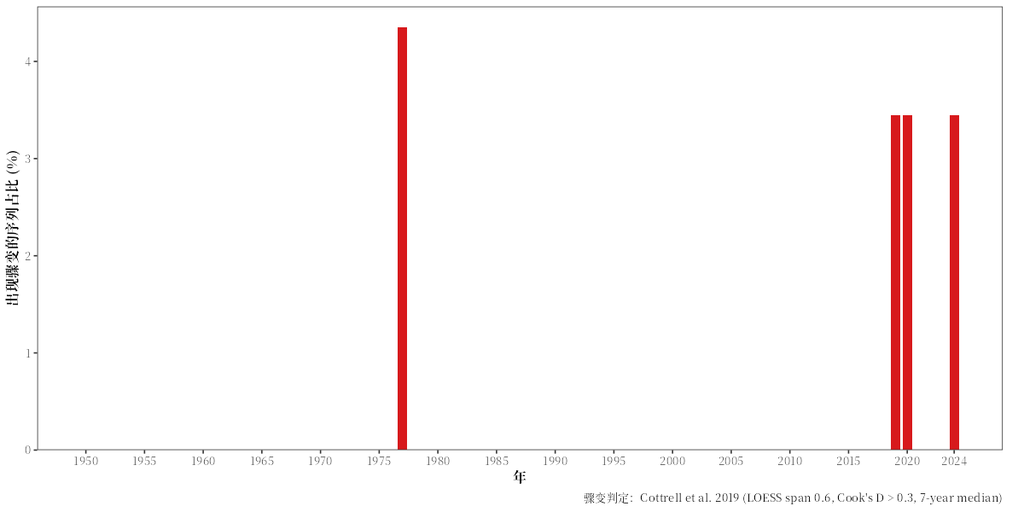

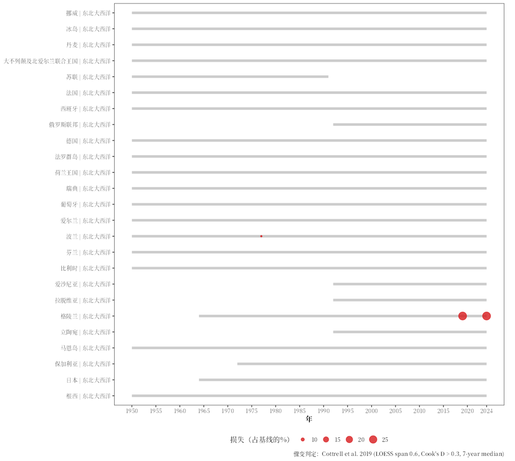

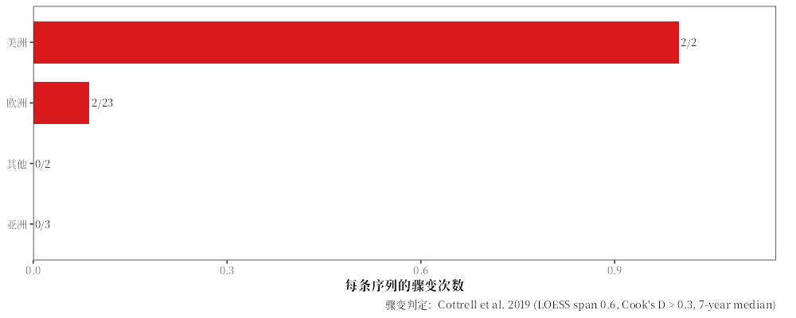

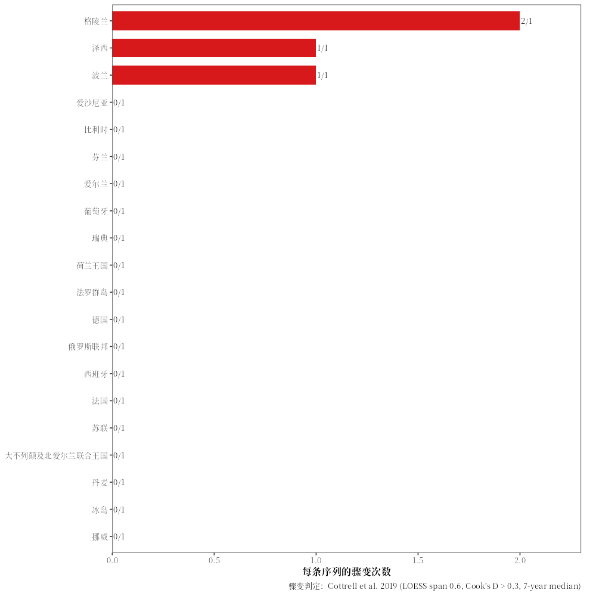

第一幅图是每年的骤变频率。第二幅图显示产量最大的`top_n`条序列从首年到末年的时间范围，每次骤变用一个点表示，点的大小代表损失的百分比。其余的图给出各大洲和各国家的骤变率，柱旁标注骤变次数和序列数；只有一个组的分组（这里是渔区）不出图。

按损失吨数排列的最大几次骤变：

```r
largest <- shocks$shocks[order(-shocks$shocks$loss_tonnes), ]
show_table(data.frame(largest[, c("series_name", "Year", "catch_tonnes", "baseline_tonnes", "loss_tonnes",
                                  "loss_pct", "cooks_distance", "recovery_years")], row.names = NULL),
           digits = c(0, 0, 0, 0, 0, 1, 2, 0))
```

| series_name | Year | catch_tonnes | baseline_tonnes | loss_tonnes | loss_pct | cooks_distance | recovery_years |
| --- | --- | --- | --- | --- | --- | --- | --- |
| 格陵兰 \| 东北大西洋 | 2024 | 89,282 | 124,106 | 34,824 | 28.1 | 0.47 | NA |
| 格陵兰 \| 东北大西洋 | 2019 | 85,189 | 118,128 | 32,939 | 27.9 | 0.32 | 3 |
| 波兰 \| 东北大西洋 | 1977 | 196,823 | 215,725 | 18,902 | 8.8 | 1.97 | 3 |
| 泽西 \| 东北大西洋 | 2020 | 992 | 1,537 | 545 | 35.5 | 0.39 | NA |

骤变频率最高的年份，以及各大洲的骤变率：

```r
show_table(data.frame(head(shocks$by_year[order(-shocks$by_year$shock_frequency_pct), ], 5), row.names = NULL))
```

| Year | n_series | n_shocks | shock_frequency_pct |
| --- | --- | --- | --- |
| 1977 | 23 | 1 | 4.35 |
| 2019 | 29 | 1 | 3.45 |
| 2020 | 29 | 1 | 3.45 |
| 2024 | 29 | 1 | 3.45 |
| 1950 | 18 | 0 | 0.00 |

```r
show_table(data.frame(subset(shocks$by_group, grouping == "continent"), row.names = NULL))
```

| grouping | group | group_name | n_series | n_shocks | shocks_per_series |
| --- | --- | --- | --- | --- | --- |
| continent | Americas | 美洲 | 2 | 2 | 1.00 |
| continent | Europe | 欧洲 | 23 | 2 | 0.09 |
| continent | Asia | 亚洲 | 3 | 0 | 0.00 |
| continent | Other | 其他 | 2 | 0 | 0.00 |

### 其他设置

Gephart et al. (2017)的方法。文件名中不含方法名，所以用`label`避免这次调用的图表覆盖第一次调用的图表：

```r
gephart <- catch_shocks(FAO27$area_data, method = "gephart2017", label = "FAO27 gephart2017")
```

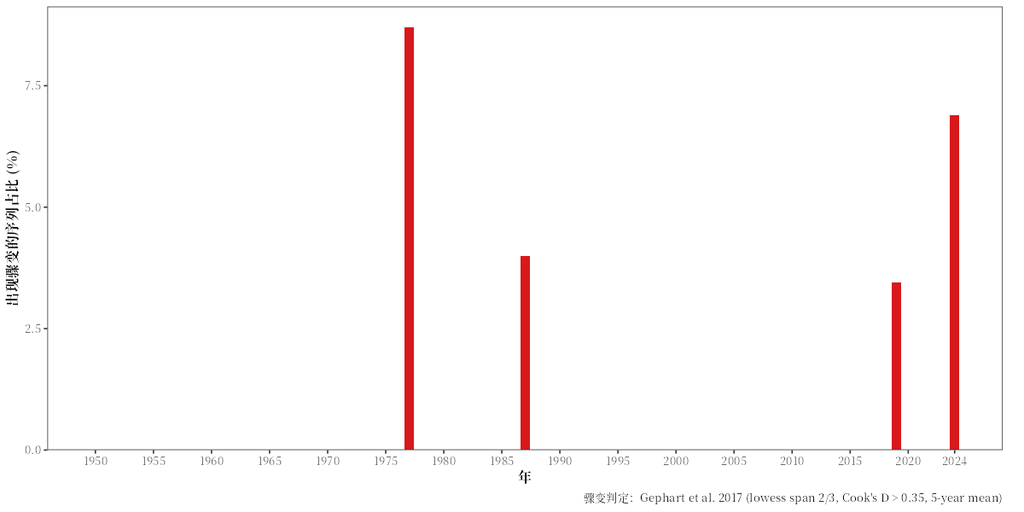

```r
both <- merge(shocks$shocks[, c("series", "Year")], gephart$shocks[, c("series", "Year")])
c(cottrell2019 = nrow(shocks$shocks), gephart2017 = nrow(gephart$shocks), both = nrow(both))
```

```
#> cottrell2019  gephart2017         both
#>            4            6            3
```

两种方法分别找到4次和6次骤变，其中只有3次落在相同的序列和年份：许多年份的库克距离都接近阈值，这些临界情况取决于平滑方法和基线。两种方法都能得到的结果更为可靠。

`by = "species"`时，一条序列是一个物种条目在该渔区的产量（所有国家合计），骤变率还会按ISSCAAP物种类群给出：

```r
species_shocks <- catch_shocks(FAO27$area_data, by = "species", label = "FAO27 species")
```

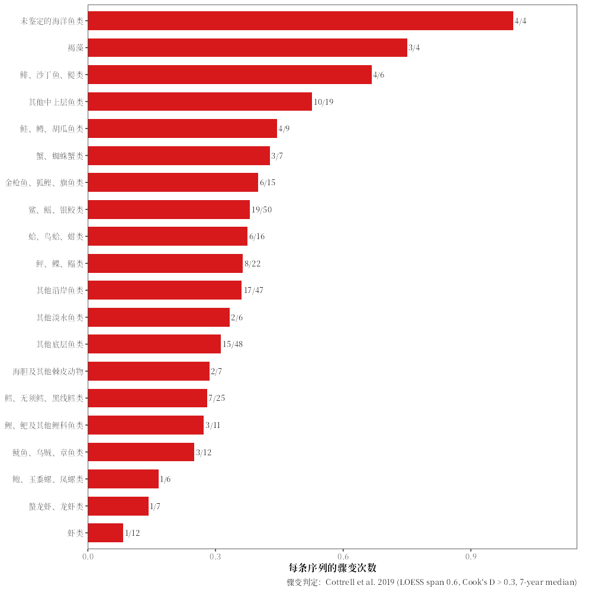

```r
groups <- subset(species_shocks$by_group, grouping == "species_group" & n_series >= 5)
show_table(data.frame(groups[, c("group_name", "n_series", "n_shocks", "shocks_per_series")], row.names = NULL))
```

| group_name | n_series | n_shocks | shocks_per_series |
| --- | --- | --- | --- |
| 鲱、沙丁鱼、鳀类 | 6 | 4 | 0.67 |
| 其他中上层鱼类 | 19 | 10 | 0.53 |
| 鲑、鳟、胡瓜鱼类 | 9 | 4 | 0.44 |
| 蟹、蜘蛛蟹类 | 7 | 3 | 0.43 |
| 金枪鱼、狐鲣、旗鱼类 | 15 | 6 | 0.40 |
| 鲨、鳐、银鲛类 | 50 | 19 | 0.38 |
| 蛤、鸟蛤、蚶类 | 16 | 6 | 0.38 |
| 鲆、鲽、鳎类 | 22 | 8 | 0.36 |
| 其他沿岸鱼类 | 47 | 17 | 0.36 |
| 其他淡水鱼类 | 6 | 2 | 0.33 |

两项原始研究分析的是各国的全国总量，即一个国家所有物种和渔区的合计。使用全部渔区的数据并设`by = "country"`，即可得到同样的序列（耗时较长）：

```r
catch_shocks(load_fao_data(), by = "country", method = "gephart2017")
```

### 参数与返回值

| 参数 | 含义 | 默认值 |
| --- | --- | --- |
| `area_data` | FAO产量数据：`fishing_area_data()$area_data`，或`load_fao_data()`的任意子集 |  |
| `by` | 序列的定义：`"country"`、`"area"`和`"species"`中的一个或多个 | `c("country", "area")` |
| `method` | `"cottrell2019"`或`"gephart2017"` | `"cottrell2019"` |
| `min_years` | 有产量的年数少于该值的序列不纳入分析 | `20` |
| `top_n` | 时间线图中显示的产量最大的序列数 | `25` |
| `plot`、`table`、`lang`、`pptx`、`label` | 通用参数（见本文开头） |  |

| 元素 | 内容 |
| --- | --- |
| `shocks` | 每次骤变一行：所属序列、`Year`、`catch_tonnes`、`baseline_tonnes`、`loss_tonnes`、`loss_pct`、`cooks_distance`和`recovery_years` |
| `by_year` | 每年的`n_series`（当年参与分析的序列数，包括产量降到零的序列）、`n_shocks`和`shock_frequency_pct` |
| `by_group` | 按`grouping`（国家、渔区、物种、大洲、物种类群）统计的骤变率：`n_series`、`n_shocks`和`shocks_per_series` |
| `series` | 参与分析的序列：`first_year`、`last_year`、`n_years`、`total_tonnes`和`n_shocks` |

- 两项原始研究分析的都是全国总量。一个国家在一个渔区的序列，或一个物种的序列，是把同一方法用于更小的单元。
- 波动剧烈的序列（如秘鲁鳀）可能不出现骤变，因为大幅变化在这类序列中很常见（Gephart et al. 2017）。
- 骤变只是产量序列中的异常，可能源于资源本身、环境、市场、管理或统计报告方式的变化，产量数据本身无法区分。
- 平滑和回归都使用整条序列，所以增加一年的新数据，可能改变较早的年份是否被判定为骤变。

## 💥 渔业崩溃

根据产量数据判定崩溃，常用的定义有两种。Mullon et al. (2005)统计了FAO产量序列中的崩溃，并描述了崩溃前产量下降的形态；Worm et al. (2006)跟踪产量低于其最高值10%的渔业所占的比例。Wilberg and Miller (2007)指出，即使是没有趋势的随机序列，按第二种指标计算的比例也会上升，所以`collapse_analysis()`会把数据与这样的随机序列进行比较。

### 方法

|  | `"mullon2005"`（默认） | `"worm2006"` |
| --- | --- | --- |
| 一条序列 | 一个国家在一个FAO渔区捕捞的一个物种或属 | 一个物种条目在一个FAO渔区的产量，所有国家合计 |
| 不纳入分析 | 未鉴定到属或种的条目；`exclude_countries`中的国家；最后`complete_years`（20）年中有缺失年份的序列；年平均产量低于`min_mean_catch`（500吨）的序列 | 总产量低于`min_total_catch`（1万吨）的渔业 |
| 崩溃 | 在最高产量$X_{max}$出现的年份之后，产量连续4年低于$X_{max}/10$；其中第一年为崩溃年份$D_c$（Mullon et al. 2005，第113页） | 产量低于最高值10%的年份即处于崩溃状态，回升到10%以上即为恢复。渔业从产量首次达到最高值10%的年份算起 |
| 结果 | 崩溃次数、崩溃年份和崩溃前的下降形态 | 每年处于崩溃状态的渔业比例，以及曾经崩溃的渔业比例（Worm et al. 2006，正文及补充材料第4–5页） |

`exclude_countries`默认包含Mullon et al. (2005)第112页排除的国家：前苏联、南斯拉夫和捷克斯洛伐克，它们的序列随国家解体而中断；南非和纳米比亚，它们的序列曾被拆分；以及中国，作者认为其序列失真。

**下降形态**（Mullon et al. 2005，第114页）按以下顺序判定（原文没有说明判定顺序）：

| 类型 | 规则 |
| --- | --- |
| 平台型 | 从$D_c - 8$到$D_c - 3$的每一年产量都高于$X_{max}/4$：长期高产之后突然下降 |
| 平滑型 | 从$D_c - 10$到$D_c$产量与时间的相关系数低于$-0.7$：长期、平稳的下降 |
| 波动型 | 其余情况：几经起伏之后的下降 |
| 未分类 | 发生在序列首年之后不足10年的崩溃 |

Mullon et al.在1950–2000年的1519条FAO序列中发现366次崩溃（24%）：平台型占21%，平滑型占33%，波动型占45%。

**零模型**：序列的最高值随序列长度增加而增大，因此即使什么都没有变化，以最高值为参照定义的“崩溃”渔业比例也会随时间上升（Wilberg and Miller 2007）。`null_model = TRUE`（默认）时，函数在`n_sim`（100）组无趋势的随机序列上重复同样的分析，随机序列的起始年份和长度与真实序列相同。与Wilberg and Miller (2007)一样，这些序列是平稳的一阶自回归对数正态序列：$x_t = \rho\,x_{t-1} + \varepsilon_t$，其中$\rho = 0.75$，$\varepsilon_t \sim N\!\left(0,\ \sigma^2 (1 - \rho^2)\right)$，产量$= e^{x_t}$；$\sigma^2 = \ln(1 + \text{CV}^2)$，对应80%的变异系数。随机序列中的崩溃比例，就是定义本身所产生的水平。

**随机数**：每次运行都会重新抽取随机序列，所以零模型的结果每次略有不同。在调用前使用`set.seed()`可以固定结果。本页使用`set.seed(1)`，使网站每次构建时正文中的数字都与表格一致；`fao_report()`用`collapse_seed`（默认为1）做同样的处理。

### 示例

```r
set.seed(1)   # 固定零模型的随机序列
collapses <- collapse_analysis(FAO27$area_data)
```

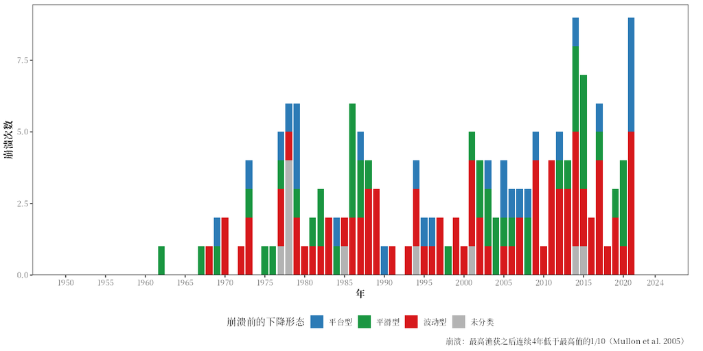

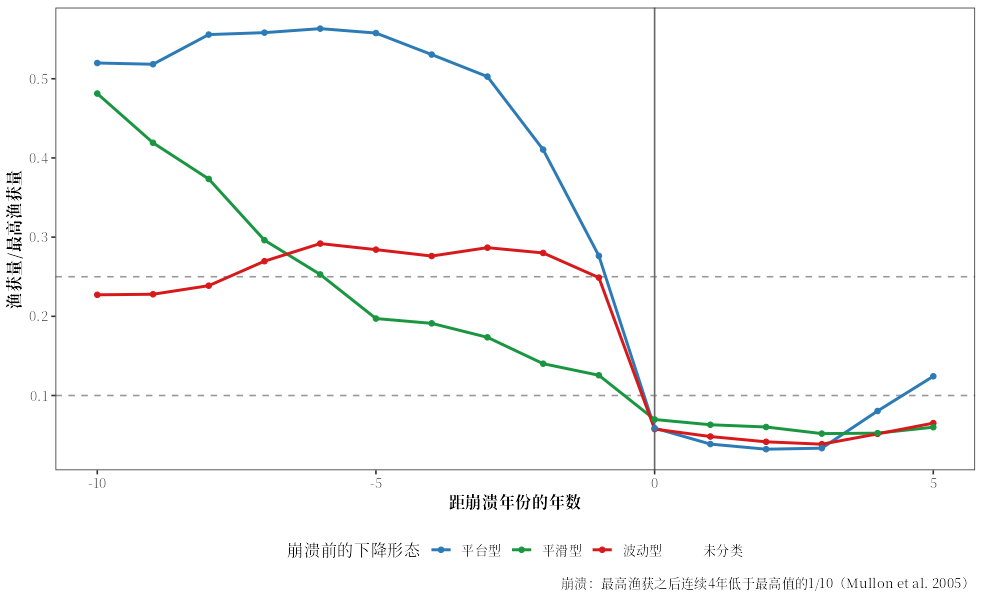

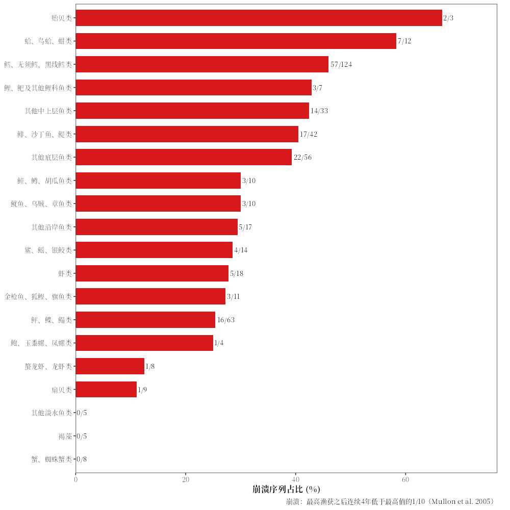

第一幅图是每年的崩溃次数，按下降形态区分。第二幅图是各类型崩溃前后的平均产量（相对于各自的最高值），从崩溃前10年到崩溃后5年；虚线为$X_{max}/4$和$X_{max}/10$。第三幅图是至少有3条序列的ISSCAAP物种类群中崩溃序列所占的比例。

```r
s <- collapses$summary
show_table(data.frame(s, row.names = NULL), digits = 1)
```

| type | n | pct_of_series | pct_of_collapses | n_series | null_pct_of_series |
| --- | --- | --- | --- | --- | --- |
| collapsed | 166 | 35.9 | 100.0 | 463 | 22.6 |
| plateau | 27 | 5.8 | 16.3 | 463 | NA |
| smooth | 45 | 9.7 | 27.1 | 463 | NA |
| erratic | 84 | 18.1 | 50.6 | 463 | NA |
| not classified | 10 | 2.2 | 6.0 | 463 | NA |

最高产量最大的崩溃序列，以及各物种类群的崩溃比例：

```r
collapsed <- subset(collapses$series, collapsed)
collapsed <- collapsed[order(-collapsed$max_tonnes), c("series_name", "max_year", "max_tonnes", "collapse_year", "type")]
show_table(data.frame(collapsed, row.names = NULL), digits = 0)
```

| series_name | max_year | max_tonnes | collapse_year | type |
| --- | --- | --- | --- | --- |
| 挪威 \| 毛鳞鱼 \| 东北大西洋 | 1977 | 2,115,701 | 1987 | plateau |
| 挪威 \| 大西洋鲱 \| 东北大西洋 | 1954 | 1,461,500 | 1973 | erratic |
| 挪威 \| 大西洋鲭 \| 东北大西洋 | 1967 | 868,600 | 1980 | erratic |
| 冰岛 \| 大西洋鲱 \| 东北大西洋 | 1966 | 770,700 | 1969 | plateau |
| 丹麦 \| 挪威长臀鳕 \| 东北大西洋 | 1974 | 475,142 | 2003 | smooth |
| 大不列颠及北爱尔兰联合王国 \| 大西洋鳕 \| 东北大西洋 | 1956 | 474,900 | 2000 | erratic |
| 俄罗斯联邦 \| 毛鳞鱼 \| 东北大西洋 | 1992 | 424,781 | 1994 | not classified |
| 丹麦 \| 黑线鳕 \| 东北大西洋 | 1969 | 317,500 | 1977 | erratic |
| 挪威 \| 挪威长臀鳕 \| 东北大西洋 | 1975 | 308,806 | 2001 | smooth |
| 丹麦 \| 大西洋鳕 \| 东北大西洋 | 1981 | 194,716 | 2017 | erratic |

```r
groups <- subset(collapses$by_group, grouping == "species_group" & n_series >= 3)
show_table(data.frame(groups[, c("group_name", "n_series", "n_collapsed", "pct_collapsed")], row.names = NULL), digits = 1)
```

| group_name | n_series | n_collapsed | pct_collapsed |
| --- | --- | --- | --- |
| 鳕、无须鳕、黑线鳕类 | 124 | 57 | 46.0 |
| 鲆、鲽、鳎类 | 63 | 16 | 25.4 |
| 其他底层鱼类 | 56 | 22 | 39.3 |
| 鲱、沙丁鱼、鳀类 | 42 | 17 | 40.5 |
| 其他中上层鱼类 | 33 | 14 | 42.4 |
| 虾类 | 18 | 5 | 27.8 |
| 其他沿岸鱼类 | 17 | 5 | 29.4 |
| 鲨、鳐、银鲛类 | 14 | 4 | 28.6 |
| 蛤、鸟蛤、蚶类 | 12 | 7 | 58.3 |
| 金枪鱼、狐鲣、旗鱼类 | 11 | 3 | 27.3 |

**结果解读**：按Mullon et al. (2005)的定义，27区463条序列中有166条（35.9%）发生了崩溃，而无趋势的随机序列中这一比例为22.6%。指向真实崩溃的是两者之差，而不是比例本身。在所有崩溃中，波动型占51%，平台型占16%，平滑型占27%。平台型崩溃最难预见：产量在骤降之前一直保持在高位（Mullon et al. 2005）。

### 其他设置

Worm et al. (2006)的定义，使用同样的种子：

```r
set.seed(1)
worm <- collapse_analysis(FAO27$area_data, method = "worm2006")
```

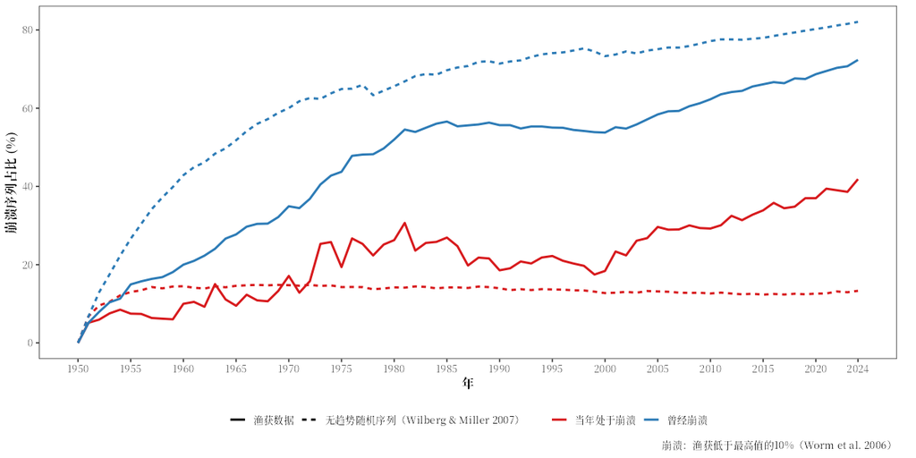

```r
show_table(data.frame(worm$summary, row.names = NULL), digits = 1)
```

| type | n | n_series | pct_of_series | null_pct_of_series |
| --- | --- | --- | --- | --- |
| collapsed in the last year | 103 | 246 | 41.9 | 13.3 |
| collapsed at least once | 178 | 246 | 72.4 | 82.1 |

```r
show_table(data.frame(subset(worm$by_year, Year %in% c(1960, 1980, 2000, max(Year))), row.names = NULL), digits = 1)
```

| Year | n_fisheries | n_collapsed | n_ever_collapsed | pct_current | pct_cumulative | null_pct_current | null_pct_cumulative |
| --- | --- | --- | --- | --- | --- | --- | --- |
| 1960 | 120 | 12 | 24 | 10.0 | 20.0 | 14.5 | 42.9 |
| 1980 | 175 | 46 | 91 | 26.3 | 52.0 | 14.2 | 65.6 |
| 2000 | 212 | 39 | 114 | 18.4 | 53.8 | 12.7 | 73.3 |
| 2024 | 246 | 103 | 178 | 41.9 | 72.4 | 13.3 | 82.1 |

到最后一年，27区有72.4%的渔业至少崩溃过一次，而无趋势的随机序列为82.1%：在这个渔区，不断上升的累计比例来自定义本身，这正是Wilberg and Miller (2007)指出的问题。最后一年处于崩溃状态的比例（41.9%，零模型为13.3%）是更好的指标。

另外三项设置也常用：`exclude_countries = character(0)`在Mullon et al.的方法中保留所有国家；`null_model = FALSE`不生成随机序列，运行更快；`n_sim = 1000`使零模型的结果更稳定。

### 参数与返回值

| 参数 | 含义 | 默认值 |
| --- | --- | --- |
| `area_data` | FAO产量数据：`fishing_area_data()$area_data`，或`load_fao_data()`的任意子集 |  |
| `method` | `"mullon2005"`或`"worm2006"` | `"mullon2005"` |
| `exclude_countries` | `"mullon2005"`方法中不纳入分析的国家 | `c("Un. Sov. Soc. Rep.", "Yugoslavia SFR", "Czechoslovakia", "South Africa", "Namibia", "China")` |
| `complete_years` | `"mullon2005"`方法中，序列在数据的最后这么多年里每年都须有记录 | `20` |
| `min_mean_catch` | `"mullon2005"`方法中，序列的最低年平均产量（吨） | `500` |
| `min_total_catch` | `"worm2006"`方法中，渔业的最低总产量（吨） | `10000` |
| `null_model` | 是否在无趋势的随机序列上重复分析（Wilberg and Miller 2007） | `TRUE` |
| `n_sim` | 零模型随机数据集的组数 | `100` |
| `plot`、`table`、`lang`、`pptx`、`label` | 通用参数（见本文开头） |  |

| 元素 | 内容 |
| --- | --- |
| `series` | 每条序列一行：`max_year`和`max_tonnes`；`"mullon2005"`方法另有`collapsed`、`collapse_year`和`type`，`"worm2006"`方法另有`start_year`、`collapsed_last_year`和`first_collapse_year` |
| `summary` | `"mullon2005"`：崩溃次数及各类型的次数、`pct_of_series`、`pct_of_collapses`和零模型中的比例`null_pct_of_series`。`"worm2006"`：最后一年处于崩溃状态的渔业和曾经崩溃的渔业，以及零模型的对应结果 |
| `by_year` | `"mullon2005"`：按年份和类型统计的`n_collapses`。`"worm2006"`：`n_fisheries`、`n_collapsed`、`n_ever_collapsed`、`pct_current`、`pct_cumulative`，以及零模型中的相应比例 |
| `by_group` | 按FAO渔区和物种类群统计的崩溃比例：`n_series`、`n_collapsed`和`pct_collapsed` |

- 单凭产量数据，无法区分资源崩溃与管理、市场或统计报告造成的产量下降。
- 以最高值为参照的定义在随机序列中同样会产生“崩溃”。应把数据与零模型比较；零模型给出的是参照水平，而不是统计检验。
- Worm et al. (2006)使用的是Sea Around Us数据中各大海洋生态系统的物种；这里的一个渔业是FAO渔区中的一个物种条目，所以两者的比例不能直接比较。
- 使用默认的`exclude_countries`时，与Mullon et al. (2005)一样，中国的产量不纳入分析。

## 🎼 同步性与组合效应

不同物种的产量如果在不同的时间涨落，它们的总产量就比各自的产量更稳定。这就是组合效应（portfolio effect），名称来自分散投资降低风险的道理。Ong et al. (2021)分析了1092条海洋渔获序列，发现渔获越同步的海区，总渔获量越不稳定。`catch_synchrony()`衡量数据中各产量序列波动的同步程度，以及它们的不同步在多大程度上稳定了总产量。

### 方法

序列的选取与Ong et al. (2021)相同：年产量的中位数高于`min_median`（10吨），且超过`min_nonzero`（3/4）的年份有产量。`by = "species"`时只使用鉴定到种的条目（Ong et al.排除了“其他”类和未分类的nei条目）。与Ong et al.一样，每条序列先用对年份的线性回归**去趋势**，因为共同的趋势会使序列看起来同步（Lepš et al. 2019）；`detrend = "none"`则保留趋势。

记$\sigma_i$为序列$i$（去趋势后）的标准差，$\sigma_T$为总产量的标准差，$m_i$为序列$i$的平均产量，$m_T$为平均总产量：

| 指标 | 公式 | 列 |
| --- | --- | --- |
| 同步性 | $\varphi = \sigma_T^2 / \left(\sum_i \sigma_i\right)^2$，从0（波动完全相互抵消）到1（完全同步）（Loreau and de Mazancourt 2008，式9） | `synchrony_phi` |
| 总产量的变异系数 | $\text{CV}_T = \sigma_T / m_T$ | `cv_total` |
| 加权平均变异系数 | $\sum_i \sigma_i / m_T$：所有序列完全同步时总产量的变异系数 | `weighted_mean_cv` |
| 分解 | $\text{CV}_T = \sqrt{\varphi} \times \sum_i \sigma_i / m_T$（Thibaut and Connolly 2013，式2–4）：同步性越低，总产量越稳定 |  |
| 序列的平均变异系数 | $\overline{\text{CV}} = \frac{1}{n} \sum_i \sigma_i / m_i$ | `mean_cv_series` |
| 组合效应 | $100 \times (\overline{\text{CV}} - \text{CV}_T) / \text{CV}_T$：单条序列比总产量多变多少，以百分比表示（Ong et al. 2021，参照Carlson and Satterthwaite 2011） | `portfolio_effect_pct` |
| 两两相关 | 去趋势后各序列之间的相关系数：平均值及正相关所占的比例 | `mean_pairwise_correlation`、`positive_correlations_pct` |

同样的指标也在长度为`window`年（20年）的滑动窗口中计算（每个窗口内分别去除线性趋势，这是本包的选择），以显示同步性随时间的变化。Ong et al. (2021)用小波相干（wavelet coherence）衡量同步性，可以区分不同的时间尺度；本函数采用上述较简单的、基于相关的指标。

### 示例

```r
sync <- catch_synchrony(FAO27$area_data)
```

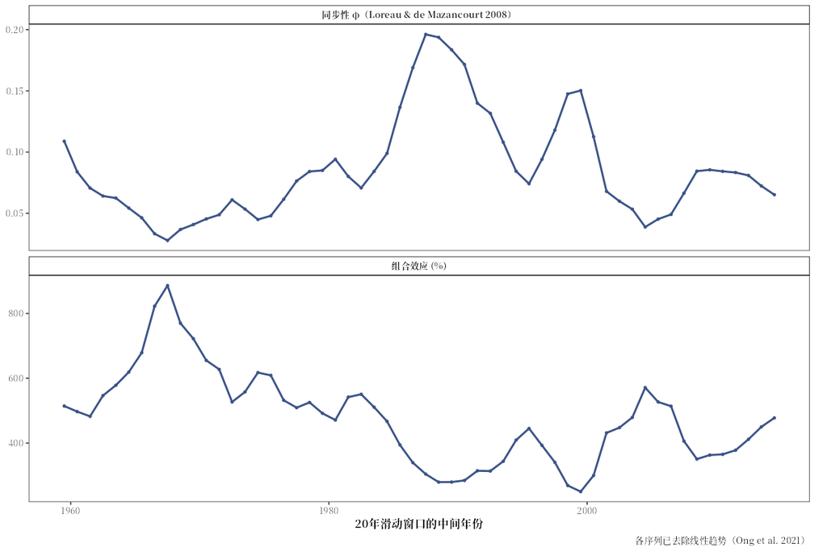

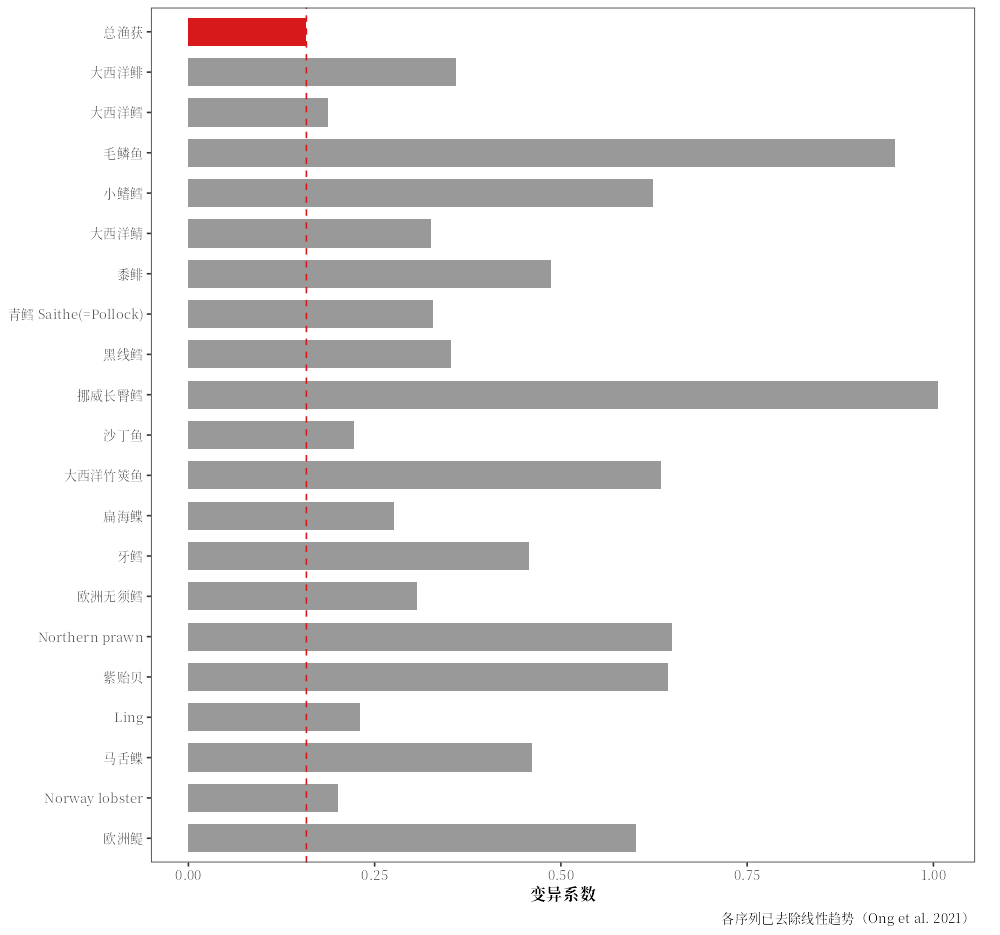

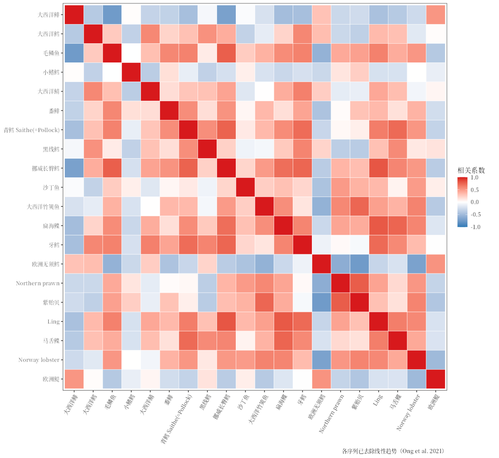

第一幅图是每个20年窗口的同步性和组合效应，标在窗口的中间年份。第二幅图比较总产量的变异系数（红色，虚线）与产量最大的`top_n`条序列的变异系数。第三幅图是这些序列之间的相关系数：红色表示同涨同落，蓝色表示相互抵消。

```r
show_table(sync$summary[, c("n_series", "synchrony_phi", "cv_total", "weighted_mean_cv", "mean_cv_series",
                            "portfolio_effect_pct", "mean_pairwise_correlation")], digits = 2)
```

| n_series | synchrony_phi | cv_total | weighted_mean_cv | mean_cv_series | portfolio_effect_pct | mean_pairwise_correlation |
| --- | --- | --- | --- | --- | --- | --- |
| 100 | 0.12 | 0.16 | 0.46 | 0.64 | 305.95 | 0.02 |

```r
with(sync$summary, c(cv_total = cv_total, decomposition = sqrt(synchrony_phi) * weighted_mean_cv))
```

```
#>      cv_total decomposition
#>     0.1583766     0.1583766
```

第二行验证Thibaut and Connolly (2013)的分解：总产量的变异系数等于$\sqrt{\varphi}$乘以加权平均变异系数。各序列的`variance_contribution_pct`是其对总产量方差的贡献，即该序列与总产量的协方差除以总产量的方差（各序列的贡献合计为100%，能抵消总产量波动的序列为负值）；`sd_share_pct`只是其标准差在$\sum_i \sigma_i$中所占的比例，没有考虑各序列之间的共同变化：

```r
show_table(sync$series[, c("series", "mean_tonnes", "sd_tonnes", "cv", "sd_share_pct", "variance_contribution_pct")], digits = 2)
```

| series | mean_tonnes | sd_tonnes | cv | sd_share_pct | variance_contribution_pct |
| --- | --- | --- | --- | --- | --- |
| 大西洋鲱 | 1,783,720.1 | 641,085.45 | 0.36 | 17.14 | -21.13 |
| 大西洋鳕 | 1,340,211.7 | 250,666.29 | 0.19 | 6.70 | 6.95 |
| 毛鳞鱼 | 963,394.1 | 913,315.70 | 0.95 | 24.42 | 58.50 |
| 小鳍鳕 | 681,303.2 | 424,417.72 | 0.62 | 11.35 | 3.77 |
| 大西洋鲭 | 594,879.2 | 193,891.44 | 0.33 | 5.18 | 6.08 |
| 黍鲱 | 379,887.1 | 184,815.48 | 0.49 | 4.94 | 10.46 |
| 青鳕 Saithe(=Pollock) | 369,793.0 | 121,278.75 | 0.33 | 3.24 | 6.85 |
| 黑线鳕 | 342,581.3 | 120,815.19 | 0.35 | 3.23 | 3.16 |
| 挪威长臀鳕 | 203,371.8 | 204,525.52 | 1.01 | 5.47 | 11.78 |
| 沙丁鱼 | 160,844.9 | 35,782.65 | 0.22 | 0.96 | 0.66 |

```r
show_table(data.frame(subset(sync$windows, first_year %% 10 == 0), row.names = NULL), digits = 2)
```

| first_year | last_year | mid_year | n_series | synchrony_phi | cv_total | mean_cv_series | portfolio_effect_pct |
| --- | --- | --- | --- | --- | --- | --- | --- |
| 1950 | 1969 | 1959.5 | 100 | 0.11 | 0.08 | 0.49 | 514.30 |
| 1960 | 1979 | 1969.5 | 100 | 0.04 | 0.06 | 0.50 | 722.09 |
| 1970 | 1989 | 1979.5 | 100 | 0.09 | 0.08 | 0.47 | 491.84 |
| 1980 | 1999 | 1989.5 | 100 | 0.18 | 0.09 | 0.35 | 279.75 |
| 1990 | 2009 | 1999.5 | 100 | 0.15 | 0.09 | 0.33 | 250.20 |
| 2000 | 2019 | 2009.5 | 100 | 0.09 | 0.07 | 0.34 | 363.01 |

**结果解读**：27区100条物种序列的同步性为0.12，远低于1：它们的波动在很大程度上相互抵消。总产量的变异系数为0.16，是所有物种同步波动时（0.46）的0.35倍（即$\sqrt{\varphi}$）。单条物种序列的变异平均是总产量的4.1倍，组合效应为306%。两条序列之间的平均相关系数为0.02。在滑动窗口中，同步性在1950–1969年为0.11，在1978–1997年达到最高的0.20，到2005–2024年降至0.07。

### 其他设置

不去趋势，以及按国家而非物种分析：

```r
none <- catch_synchrony(FAO27$area_data, detrend = "none", label = "FAO27 no detrending")
```

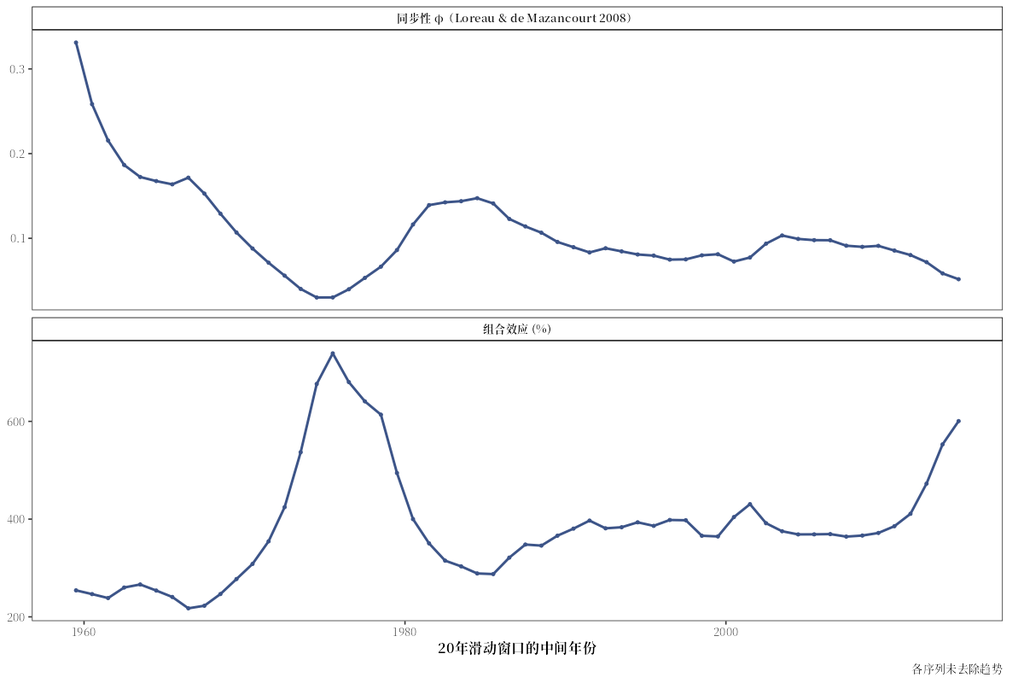

```r
countries <- catch_synchrony(FAO27$area_data, by = "country")
```

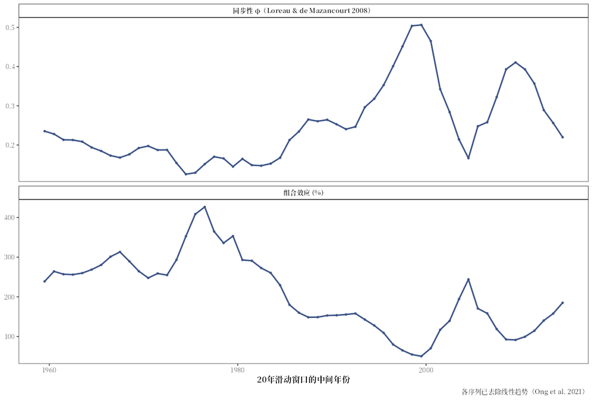

```r
settings <- rbind(sync$summary, none$summary, countries$summary)
settings$by <- c("species", "species", "country")
show_table(settings[, c("by", "detrend", "n_series", "synchrony_phi", "cv_total", "mean_cv_series",
                        "portfolio_effect_pct", "mean_pairwise_correlation")], digits = 2)
```

| by | detrend | n_series | synchrony_phi | cv_total | mean_cv_series | portfolio_effect_pct | mean_pairwise_correlation |
| --- | --- | --- | --- | --- | --- | --- | --- |
| species | linear | 100 | 0.12 | 0.16 | 0.64 | 305.95 | 0.02 |
| species | none | 100 | 0.09 | 0.16 | 0.78 | 378.89 | 0.02 |
| country | linear | 19 | 0.41 | 0.16 | 0.32 | 97.29 | 0.13 |

### 参数与返回值

| 参数 | 含义 | 默认值 |
| --- | --- | --- |
| `area_data` | FAO产量数据：`fishing_area_data()$area_data`，或`load_fao_data()`的任意子集 |  |
| `by` | 序列的定义：`"species"`或`"country"` | `"species"` |
| `detrend` | `"linear"`去除每条序列的线性趋势，`"none"`不去趋势 | `"linear"` |
| `window` | 滑动窗口的长度（年） | `20` |
| `top_n` | 变异系数图和相关图中显示的产量最大的序列数 | `20` |
| `min_median` | 序列的年产量中位数须高于该值（吨） | `10` |
| `min_nonzero` | 有产量的年份须超过该比例 | `0.75` |
| `plot`、`table`、`lang`、`pptx`、`label` | 通用参数（见本文开头） |  |

| 元素 | 内容 |
| --- | --- |
| `summary` | `n_series`、`first_year`、`last_year`、`detrend`、`synchrony_phi`、`cv_total`、`weighted_mean_cv`、`mean_cv_series`、`portfolio_effect_pct`、`mean_pairwise_correlation`和`positive_correlations_pct` |
| `series` | 各序列的`mean_tonnes`、`sd_tonnes`（去趋势后）、`cv`、`sd_share_pct`和`variance_contribution_pct` |
| `windows` | 各滑动窗口的指标：`first_year`、`last_year`、`mid_year`、`n_series`、`synchrony_phi`、`cv_total`、`mean_cv_series`和`portfolio_effect_pct`（数据不足`window` + 2年时为`NULL`） |
| `correlation` | 去趋势后各序列两两相关系数的矩阵 |

- 趋势会使序列看起来同步（Lepš et al. 2019）：解读同步性之前，先比较`detrend = "linear"`和`"none"`的结果。
- 这些指标基于相关系数。Ong et al. (2021)使用小波相干，可以区分时间尺度，并允许存在时滞。
- 渔获同步波动可能源于鱼类本身，也可能源于捕捞：Ong et al. (2021)发现，渔获的相干既可能来自生物量的相干，也可能来自捕捞死亡率的相干。
- 序列的平均变异系数不加权，所以产量小而波动大的序列会抬高组合效应；$\varphi$和加权平均变异系数则按各序列的大小加权。

## 🚢 国家的远洋捕捞概况

1950年以来，海洋渔业的作业范围扩展到越来越大的海域（Swartz et al. 2010）。`distant_water_profile()`用FAO统计数据追踪一个国家的这种扩张：该国在其邻近渔区和不相邻渔区的产量，每年作业的渔区数，以及在每个渔区的首年、末年、峰值和近期产量。

### 方法

- **远洋渔获**采用FAO的定义：一个国家在其不相邻的FAO主要渔区的产量。在本国水域以外、但仍在邻近渔区内的捕捞不算远洋渔获（Grainger and Garcia 1996，第2.6节；Garibaldi and Limongelli 2003，第2.1节）。
- 一个国家的陆地（包括海外领土）距FAO渔区边界20 km以内，该渔区即为该国的**邻近渔区**。这是本包的规则，与`coastal_distant()`相同（见🔍 数据质量、多样性与船队）。
- 一个国家某年在某渔区的产量超过`min_catch`吨（默认为0，即有任何上报的产量），该渔区就算该年**有作业**。
- 内陆渔区不纳入分析。

FAO按渔船的船旗国和FAO主要渔区记录产量，而不是按专属经济区（EEZ）。因此，概况显示的是一个国家的船队在哪些FAO渔区作业，而不是渔获来自本国水域、他国水域还是公海。Swartz et al. (2010)用Sea Around Us的渔获分布图描绘了这种扩张；本函数只用FAO统计数据，空间分辨率为FAO主要渔区。

### 示例

函数的输入是FAO数据中的国家名，使用该国在所有渔区的产量：

```r
china <- distant_water_profile("China")
```

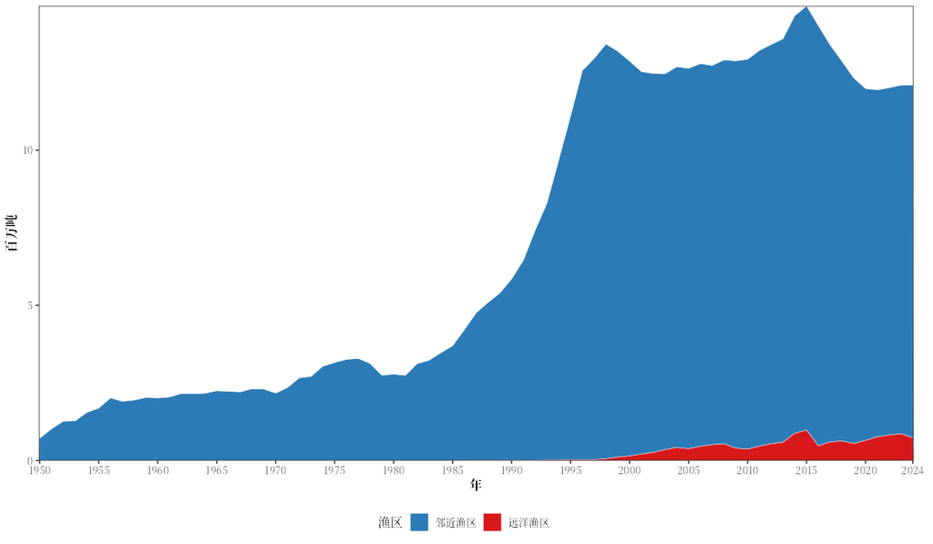

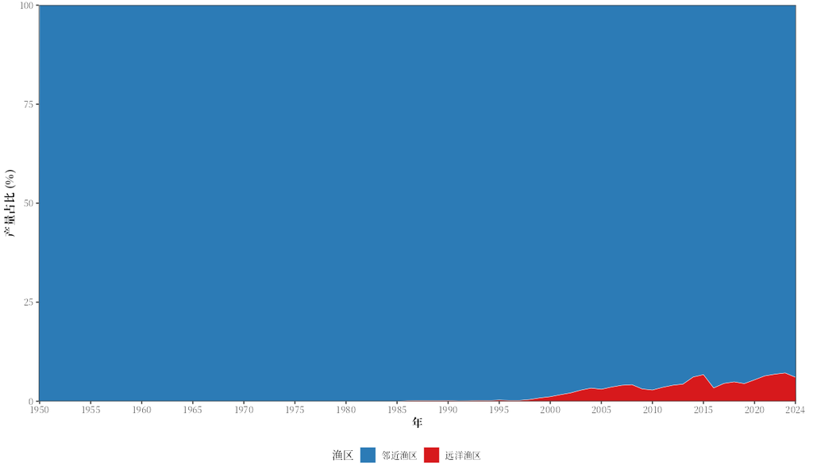

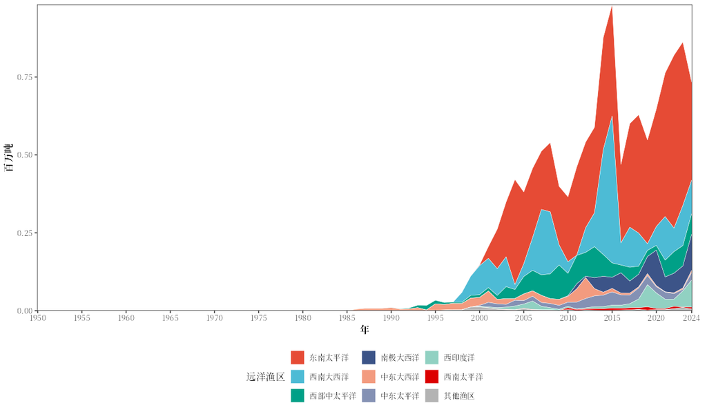

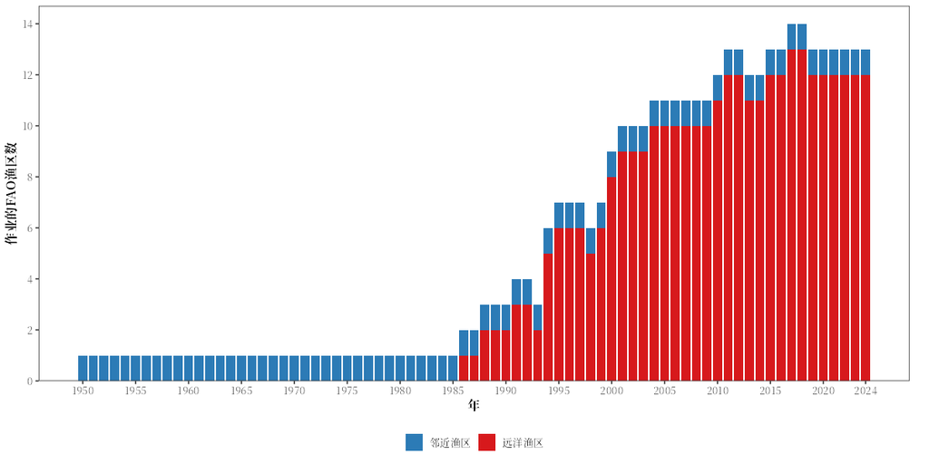

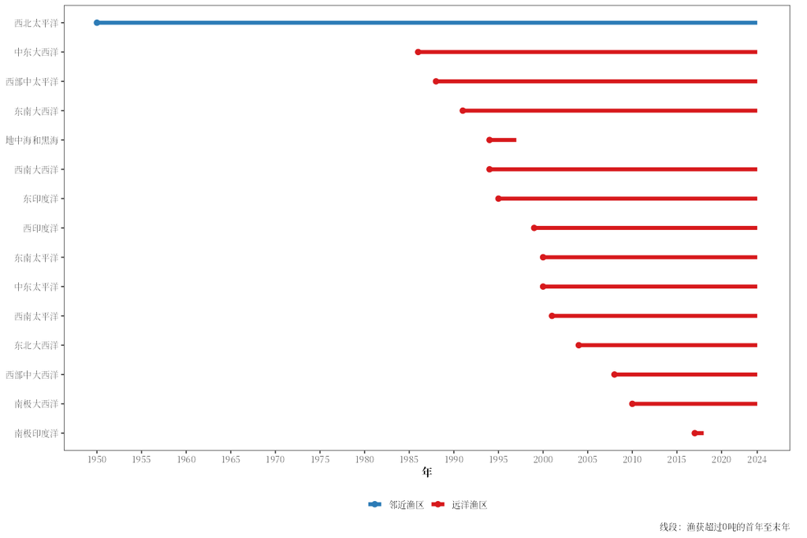

这些图依次是邻近渔区和远洋渔区的产量（吨数和占比）、各远洋渔区的产量（产量最大的`top_n`个渔区，其余合并）、每年作业的渔区数，以及每个渔区从首次到最后一次有产量的年份。

```r
show_table(data.frame(tail(china$yearly, 5), row.names = NULL), digits = 1)
```

| Year | adjacent_tonnes | distant_tonnes | distant_pct | n_adjacent_areas | n_distant_areas | n_areas |
| --- | --- | --- | --- | --- | --- | --- |
| 2020 | 11,338,947 | 647,381.8 | 5.4 | 1 | 12 | 13 |
| 2021 | 11,180,662 | 762,963.3 | 6.4 | 1 | 12 | 13 |
| 2022 | 11,192,862 | 819,959.4 | 6.8 | 1 | 12 | 13 |
| 2023 | 11,232,509 | 862,450.3 | 7.1 | 1 | 12 | 13 |
| 2024 | 11,365,630 | 733,461.8 | 6.1 | 1 | 12 | 13 |

```r
show_table(china$areas[, c("area", "adjacent", "first_year", "last_year", "peak_year", "peak_tonnes",
                           "total_tonnes", "share_of_distant_pct")], n = 20, digits = 1)
```

| area | adjacent | first_year | last_year | peak_year | peak_tonnes | total_tonnes | share_of_distant_pct |
| --- | --- | --- | --- | --- | --- | --- | --- |
| 西北太平洋 | TRUE | 1950 | 2024 | 2015 | 13,668,205.8 | 513,123,780.1 | NA |
| 东南太平洋 | FALSE | 2000 | 2024 | 2022 | 554,788.4 | 7,017,268.6 | 50.4 |
| 西南大西洋 | FALSE | 1994 | 2024 | 2015 | 471,519.0 | 2,972,602.5 | 21.4 |
| 西部中太平洋 | FALSE | 1988 | 2024 | 2009 | 110,289.0 | 1,377,376.8 | 9.9 |
| 南极大西洋 | FALSE | 2010 | 2024 | 2024 | 116,368.2 | 754,284.4 | 5.4 |
| 中东大西洋 | FALSE | 1986 | 2024 | 2012 | 67,402.0 | 576,779.9 | 4.1 |
| 中东太平洋 | FALSE | 2000 | 2024 | 2015 | 42,492.0 | 517,196.8 | 3.7 |
| 西印度洋 | FALSE | 1999 | 2024 | 2024 | 86,845.8 | 486,670.6 | 3.5 |
| 西南太平洋 | FALSE | 2001 | 2024 | 2019 | 10,802.0 | 85,474.1 | 0.6 |
| 东印度洋 | FALSE | 1995 | 2024 | 2023 | 6,451.9 | 66,412.3 | 0.5 |
| 东南大西洋 | FALSE | 1991 | 2024 | 2000 | 7,059.0 | 39,749.4 | 0.3 |
| 西部中大西洋 | FALSE | 2008 | 2024 | 2023 | 1,872.0 | 7,402.1 | 0.1 |
| 东北大西洋 | FALSE | 2004 | 2024 | 2005 | 5,587.0 | 7,358.2 | 0.1 |
| 南极印度洋 | FALSE | 2017 | 2018 | 2017 | 513.0 | 770.9 | 0.0 |
| 地中海和黑海 | FALSE | 1994 | 1997 | 1995 | 137.0 | 376.0 | 0.0 |

`share_of_distant_pct`是各远洋渔区在该国整个时期全部远洋渔获中所占的比例。中国只与西北太平洋（61区）相邻。中国在2004年首次上报27区的产量，27区占其远洋渔获的0.1%。

FAO指出，2022年中国上报了230万吨远洋渔获，但只对在中国上岸的渔获（61区）给出了物种和渔区。FAO用区域渔业管理组织的数据补充了其他渔区，并把130万吨记为61区的“Marine fishes nei”（FAO 2024）。因此，中国近年的远洋渔获有一部分计入了与其相邻的61区。

### 其他设置

西班牙，设`min_catch = 100`：只有产量超过100吨的年份才算在该渔区有作业：

```r
spain <- distant_water_profile("Spain", min_catch = 100)
```

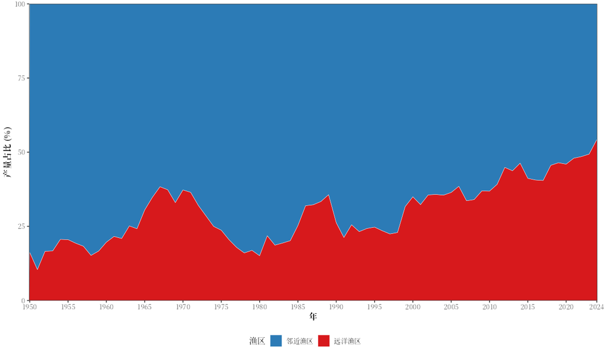

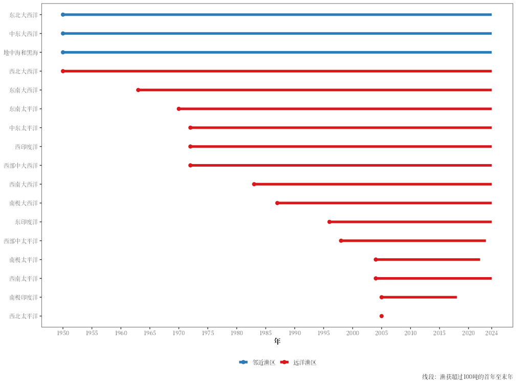

```r
show_table(spain$areas[, c("area", "adjacent", "first_year", "last_year", "peak_year", "peak_tonnes",
                           "total_tonnes", "share_of_distant_pct")], n = 20, digits = 1)
```

| area | adjacent | first_year | last_year | peak_year | peak_tonnes | total_tonnes | share_of_distant_pct |
| --- | --- | --- | --- | --- | --- | --- | --- |
| 东北大西洋 | TRUE | 1950 | 2024 | 1969 | 614,352.0 | 31,240,735.4 | NA |
| 中东大西洋 | TRUE | 1950 | 2024 | 1978 | 489,815.0 | 15,248,549.1 | NA |
| 地中海和黑海 | TRUE | 1950 | 2024 | 1982 | 163,022.0 | 8,755,909.8 | NA |
| 西北大西洋 | FALSE | 1950 | 2024 | 1968 | 341,312.0 | 6,661,750.2 | 28.6 |
| 东南大西洋 | FALSE | 1963 | 2024 | 1970 | 246,000.0 | 5,457,179.9 | 23.4 |
| 西印度洋 | FALSE | 1972 | 2024 | 2006 | 210,247.0 | 5,403,857.6 | 23.2 |
| 西南大西洋 | FALSE | 1983 | 2024 | 2014 | 197,658.0 | 3,844,766.4 | 16.5 |
| 东南太平洋 | FALSE | 1970 | 2024 | 2000 | 28,933.0 | 605,979.2 | 2.6 |
| 中东太平洋 | FALSE | 1972 | 2024 | 2024 | 66,924.0 | 581,127.0 | 2.5 |
| 西部中太平洋 | FALSE | 1998 | 2023 | 2013 | 45,035.0 | 418,408.1 | 1.8 |
| 西部中大西洋 | FALSE | 1972 | 2024 | 2011 | 13,217.0 | 148,548.8 | 0.6 |
| 西南太平洋 | FALSE | 2004 | 2024 | 2022 | 8,284.4 | 95,387.0 | 0.4 |
| 东印度洋 | FALSE | 1996 | 2024 | 1998 | 13,379.0 | 50,818.3 | 0.2 |
| 南极大西洋 | FALSE | 1987 | 2024 | 2003 | 882.0 | 9,504.2 | 0.0 |
| 南极太平洋 | FALSE | 2004 | 2022 | 2013 | 531.0 | 4,910.8 | 0.0 |
| 南极印度洋 | FALSE | 2005 | 2018 | 2006 | 648.0 | 2,154.1 | 0.0 |
| 西北太平洋 | FALSE | 2005 | 2005 | 2005 | 537.0 | 537.0 | 0.0 |
| 东北太平洋 | FALSE | NA | NA | 2013 | 18.0 | 18.0 | 0.0 |

西班牙与三个FAO渔区相邻：东北大西洋、地中海和黑海，以及因加那利群岛而相邻的中东大西洋。因此，西班牙在27区的产量不算远洋渔获，其`share_of_distant_pct`为空。

几个国家的远洋渔获中有多少来自27区：整个时期的比例（`share_of_distant_pct`）和最近五年的比例（`recent_share_pct`），以及最后一年远洋渔获在其海洋渔获中所占的比例（`distant_pct_latest`）：

```r
others <- c("Japan", "Bulgaria", "Romania", "Korea, Republic of")
profiles <- c(list(China = china, Spain = spain),
              sapply(others, distant_water_profile, plot = FALSE, table = FALSE, simplify = FALSE))
area27 <- do.call(rbind, lapply(names(profiles), function(country) {
  areas <- profiles[[country]]$areas
  here <- areas$area_en == "Atlantic, Northeast"
  recent <- 100 * areas$last_5_years_tonnes / sum(areas$last_5_years_tonnes[!areas$adjacent])
  data.frame(country = fao_translate(country, "country", lang = NULL),
             distant_pct_latest = tail(profiles[[country]]$yearly$distant_pct, 1),
             area27_adjacent = areas$adjacent[here],
             area27_first_year = areas$first_year[here],
             share_of_distant_pct = areas$share_of_distant_pct[here],
             recent_share_pct = ifelse(areas$adjacent[here], NA, recent[here]))
}))
show_table(area27, digits = 1)
```

| country | distant_pct_latest | area27_adjacent | area27_first_year | share_of_distant_pct | recent_share_pct |
| --- | --- | --- | --- | --- | --- |
| 中国 | 6.1 | FALSE | 2004 | 0.1 | 0.0 |
| 西班牙 | 54.2 | TRUE | 1950 | NA | NA |
| 日本 | 7.6 | FALSE | 1964 | 0.3 | 1.5 |
| 保加利亚 | 0.0 | FALSE | 1972 | 10.4 | NaN |
| 罗马尼亚 | 0.0 | FALSE | 1970 | 3.1 | NaN |
| 大韩民国 | 34.9 | FALSE | 1983 | 0.0 | 0.1 |

### 参数与返回值

| 参数 | 含义 | 默认值 |
| --- | --- | --- |
| `country_name` | FAO数据中的国家名（如`"China"`、`"Spain"`） |  |
| `top_n` | 单独显示的远洋渔区数，其余合并 | `8` |
| `min_catch` | 某年该国在某渔区的产量超过该吨数，才算该年在该渔区有作业 | `0` |
| `data_version` | 使用的FAO数据版本，见`load_fao_data()` | `"latest"` |
| `plot`、`table`、`lang`、`pptx`、`label` | 通用参数（见本文开头）；`label`默认为国家名 |  |

| 元素 | 内容 |
| --- | --- |
| `yearly` | 每年的`adjacent_tonnes`、`distant_tonnes`、`distant_pct`、`n_adjacent_areas`、`n_distant_areas`和`n_areas`（作业的渔区数） |
| `areas` | 每个有作业的FAO渔区一行：`adjacent`，产量超过`min_catch`的`first_year`和`last_year`，以及`n_years`、`peak_year`、`peak_tonnes`、`last_5_years_tonnes`、`total_tonnes`和`share_of_distant_pct`（邻近渔区为空） |
| `distant` | 各远洋渔区的逐年产量（`top_n`个渔区，其余合并） |

## 🔁 FAO数据版本之间的修订

FAO每年发布一版全球捕捞产量数据。新版本不仅增加最近一年的数据，还会在各国提交更正或更完整的数据时修订以前的年份（Garibaldi 2012）。Zeller and Pauly (2018)把只在近年数据中采用改进的统计方法、却不修订以前年份的做法称为“现时偏差”（presentist bias），它会使时间序列显示出实际并未发生的增长。`compare_releases()`逐条比较两个版本的记录，显示哪些年份和国家的数据被修订，以及修订追溯到多早。

### 方法

一条记录是一个国家、一个物种条目、一个FAO渔区在一年中的产量。两个版本中的每条记录归入以下一类：

| 类别 | 规则 |
| --- | --- |
| `revised` | 两个版本中都有，产量之差超过`tolerance`（0.5吨，即舍入误差） |
| `added` | 只在新版本中出现，且年份在旧版本已覆盖的范围内 |
| `removed` | 只在旧版本中出现 |
| `reclassified` | 在一个物种条目下被删除，又以相同的国家、渔区、年份和产量出现在另一个物种条目下，例如FAO更名或拆分物种条目时；不算修订 |
| `new year` | 年份晚于旧版本的最后一年 |
| `unchanged` | 其余记录 |

然后，函数汇总两个版本中每年的产量和各国的修订量，并统计状态标记发生变化的记录（如从估算值变为官方数据）。两个版本按本包使用的名称比较，下载时已通过FAO编码统一名称。目前还没有已发表的研究以这种方式逐条比较相继的FishStat版本：这一比较是本包提供的工具，上面两篇文献提供了背景。

### 示例

比较需要电脑上同时有两个版本。最新版本随包内置；较早的版本用`download_fao_data()`从FAO下载（每个约5 MB）。`check_fao_update()`列出可以下载的版本。

```r
check_fao_update()               # FAO网站上可以下载的版本
download_fao_data("2025.1.0")    # 下载较早的版本
```

```r
releases <- compare_releases("2025.1.0", "2026.1.0", area_name = "Atlantic, Northeast")
```

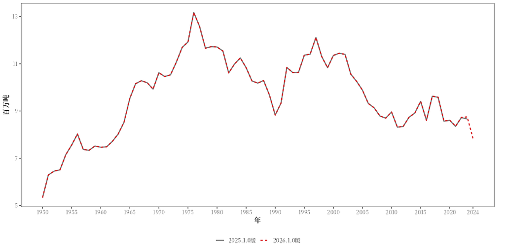

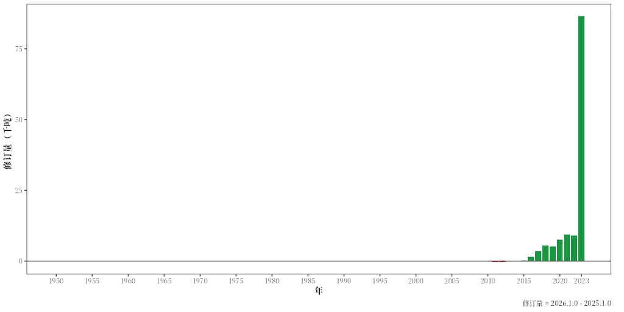

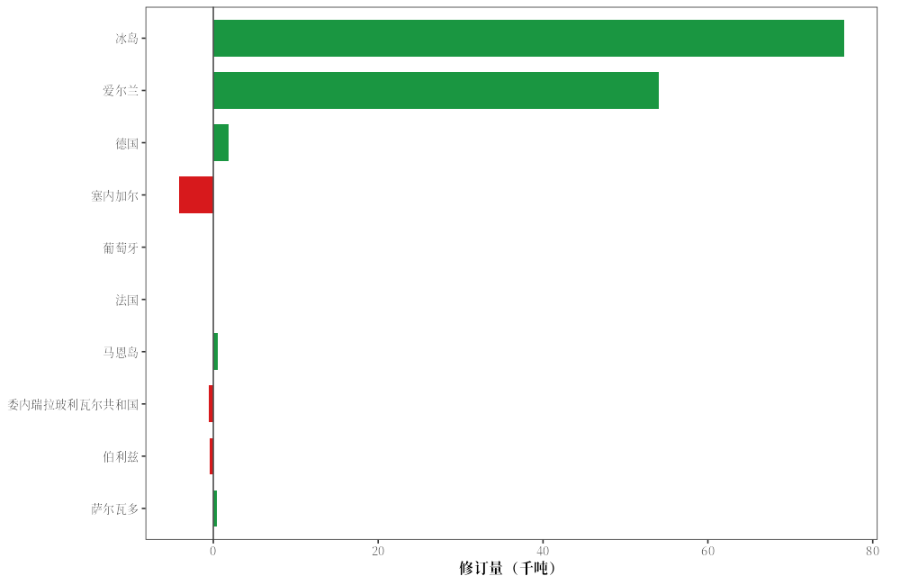

第一幅图是两个版本中每年的总产量。第二幅图是每年总产量的修订量（新版本减旧版本），单位为千吨。第三幅图是修订量最大的`top_n`个国家的净修订量，按修订量绝对值之和排序：一个国家的上调和下调相互抵消时，净修订量虽小，排名仍可能靠前。

```r
table(releases$records$change)
```

```
#>
#>        added reclassified      removed      revised
#>            9          136           35           53
```

```r
show_table(data.frame(tail(releases$by_year, 10), row.names = NULL), digits = 1)
```

| Year | old_tonnes | new_tonnes | change_tonnes | change_pct | n_revised | n_added | n_removed | n_reclassified | n_status_changed |
| --- | --- | --- | --- | --- | --- | --- | --- | --- | --- |
| 2014 | 8,914,935 | 8,914,898 | -36.6 | 0.0 | 0 | 0 | 1 | 6 | 0 |
| 2015 | 9,410,087 | 9,410,278 | 191.3 | 0.0 | 1 | 0 | 1 | 6 | 0 |
| 2016 | 8,605,840 | 8,607,412 | 1,572.4 | 0.0 | 3 | 1 | 1 | 8 | 0 |
| 2017 | 9,625,087 | 9,628,636 | 3,549.4 | 0.0 | 6 | 0 | 2 | 8 | 0 |
| 2018 | 9,581,025 | 9,586,641 | 5,615.3 | 0.1 | 4 | 0 | 3 | 6 | 0 |
| 2019 | 8,570,117 | 8,575,264 | 5,147.1 | 0.1 | 4 | 1 | 2 | 8 | 0 |
| 2020 | 8,604,066 | 8,611,702 | 7,635.2 | 0.1 | 3 | 1 | 2 | 12 | 0 |
| 2021 | 8,349,327 | 8,358,726 | 9,398.2 | 0.1 | 7 | 3 | 2 | 4 | 0 |
| 2022 | 8,722,573 | 8,731,646 | 9,073.2 | 0.1 | 4 | 0 | 3 | 8 | 0 |
| 2023 | 8,663,332 | 8,749,829 | 86,497.2 | 1.0 | 16 | 2 | 4 | 8 | 29 |

```r
show_table(releases$by_country[, c("country", "net_change_tonnes", "abs_change_tonnes", "n_records",
                                   "first_year", "last_year")], digits = 0)
```

| country | net_change_tonnes | abs_change_tonnes | n_records | first_year | last_year |
| --- | --- | --- | --- | --- | --- |
| 冰岛 | 76,551 | 76,551 | 1 | 2023 | 2023 |
| 爱尔兰 | 54,000 | 54,000 | 8 | 2016 | 2023 |
| 德国 | 1,844 | 5,168 | 5 | 2021 | 2022 |
| 塞内加尔 | -4,189 | 4,465 | 20 | 2011 | 2023 |
| 葡萄牙 | 0 | 3,410 | 10 | 2007 | 2011 |
| 法国 | 0 | 1,999 | 12 | 2018 | 2023 |
| 马恩岛 | 521 | 1,279 | 13 | 2023 | 2023 |
| 委内瑞拉玻利瓦尔共和国 | -524 | 524 | 10 | 2011 | 2023 |
| 伯利兹 | -448 | 450 | 2 | 2016 | 2019 |
| 萨尔瓦多 | 425 | 425 | 3 | 2015 | 2021 |

`records`只保留发生变化的记录。修订量最大的记录：

```r
records <- releases$records[order(-abs(releases$records$difference)), ]
show_table(data.frame(records[, c("country_name", "species_name", "Year", "tonnes_old", "tonnes_new",
                                  "difference", "change", "status_old", "status_new")], row.names = NULL),
           digits = 0)
```

| country_name | species_name | Year | tonnes_old | tonnes_new | difference | change | status_old | status_new |
| --- | --- | --- | --- | --- | --- | --- | --- | --- |
| 冰岛 | 大西洋鲱 | 2023 | 109,769 | 186,320 | 76,551 | revised | actual | actual |
| 爱尔兰 | 泡叶藻 | 2022 | 28,000 | 38,000 | 10,000 | revised | estimate | estimate |
| 爱尔兰 | 泡叶藻 | 2023 | 28,000 | 38,000 | 10,000 | revised | estimate | estimate |
| 爱尔兰 | 泡叶藻 | 2020 | 28,000 | 36,000 | 8,000 | revised | estimate | estimate |
| 爱尔兰 | 泡叶藻 | 2021 | 28,000 | 36,000 | 8,000 | revised | estimate | estimate |
| 爱尔兰 | 泡叶藻 | 2018 | 28,000 | 34,000 | 6,000 | revised | estimate | estimate |
| 爱尔兰 | 泡叶藻 | 2019 | 28,000 | 34,000 | 6,000 | revised | estimate | estimate |
| 爱尔兰 | 泡叶藻 | 2017 | 28,000 | 32,000 | 4,000 | revised | estimate | estimate |
| 德国 | Beaked redfish | 2021 | NA | 2,140 | 2,140 | added | NA | actual |
| 爱尔兰 | 泡叶藻 | 2016 | 28,000 | 30,000 | 2,000 | revised | estimate | estimate |

**结果解读**：两个版本之间，27区有53条记录被修订，9条新增，35条删除。它们大多集中在旧版本覆盖的最后十年（被修订的记录中有48条），修订量最大的是最后一年：2023年的总产量上调了8.6万吨（1%）。136条重新归类的记录是从一个物种条目移到另一个物种条目的产量，不影响总量。

### 其他设置

只比较一个国家，忽略100吨及以下的变化：

```r
iceland <- compare_releases("2025.1.0", "2026.1.0", area_name = "Atlantic, Northeast",
                            country_name = "Iceland", tolerance = 100)
```

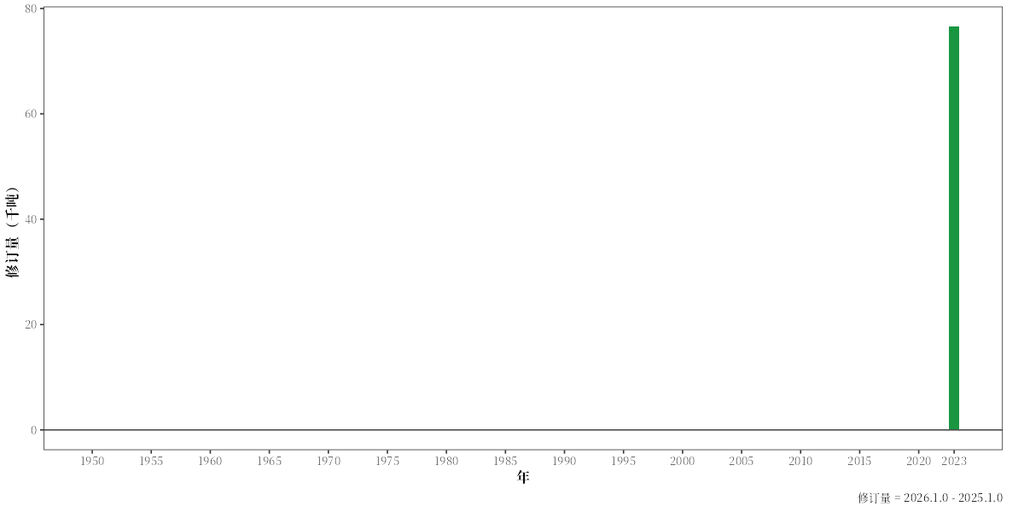

```r
revised <- subset(iceland$by_year, n_revised + n_added + n_removed > 0)
show_table(data.frame(revised[, c("Year", "old_tonnes", "new_tonnes", "change_tonnes", "change_pct",
                                  "n_revised", "n_added", "n_removed", "n_status_changed")], row.names = NULL),
           digits = 1)
```

| Year | old_tonnes | new_tonnes | change_tonnes | change_pct | n_revised | n_added | n_removed | n_status_changed |
| --- | --- | --- | --- | --- | --- | --- | --- | --- |
| 2023 | 1,371,088 | 1,447,639 | 76,551 | 5.6 | 1 | 0 | 0 | 0 |

冰岛只有2023年的产量变化超过100吨，使该年总量上调了5.6%。不给出`area_name`和`country_name`时比较整个数据集；不给出`old`和`new`时，比较电脑上最新的版本与它的前一个版本。

### 参数与返回值

| 参数 | 含义 | 默认值 |
| --- | --- | --- |
| `old`、`new` | 要比较的版本，如`"2025.1.0"`和`"2026.1.0"`；`"bundled"`表示随包内置的数据 | `NULL`：`new`为电脑上最新的版本，`old`为它的前一个版本 |
| `area_name` | 要比较的FAO渔区 | `NULL`（全部） |
| `country_name` | 要比较的国家 | `NULL`（全部） |
| `tolerance` | 不超过该吨数的变化忽略不计 | `0.5` |
| `top_n` | 国家图中显示的修订量最大的国家数 | `10` |
| `data_dir` | 下载的版本所在的文件夹 | `fao_data_dir()` |
| `plot`、`table`、`lang`、`pptx`、`label` | 通用参数（见本文开头）；`label`默认为所比较的渔区和国家 |  |

| 元素 | 内容 |
| --- | --- |
| `by_year` | 旧版本覆盖的每一年：`old_tonnes`、`new_tonnes`、`change_tonnes`、`change_pct`，以及各类记录的条数`n_revised`、`n_added`、`n_removed`、`n_reclassified`和`n_status_changed` |
| `by_country` | 各国的修订（不含重新归类的记录）：`net_change_tonnes`、`abs_change_tonnes`、`n_records`、`first_year`和`last_year` |
| `records` | 所有被修订、新增、删除或重新归类的记录：`tonnes_old`、`tonnes_new`、`status_old`、`status_new`、`difference`、`change`和`status_changed` |
| `releases` | 所比较的两个版本 |

- 近年的数据修订最多，因为它们首次发布时往往是临时数据或估算值（见🔍 数据质量、多样性与船队中的`data_quality()`）。
- 只有同样的产量移到另一个物种条目时，记录才算重新归类。FAO把一个条目拆分为几个产量不同的条目时，这一变化会显示为删除和新增的记录。
- 修订显示的是FAO改动了什么，而不是哪个版本正确。

## 📖 参考文献

Carlson, S.M. and Satterthwaite, W.H. (2011). Weakened portfolio effect in a collapsed salmon population complex. *Canadian Journal of Fisheries and Aquatic Sciences* 68: 1579–1589. [doi:10.1139/f2011-084](https://doi.org/10.1139/f2011-084)

Cottrell, R.S., Nash, K.L., Halpern, B.S., Remenyi, T.A., Corney, S.P., Fleming, A., Fulton, E.A., Hornborg, S., Johne, A., Watson, R.A. and Blanchard, J.L. (2019). Food production shocks across land and sea. *Nature Sustainability* 2: 130–137. [doi:10.1038/s41893-018-0210-1](https://doi.org/10.1038/s41893-018-0210-1)

FAO (2024). *The State of World Fisheries and Aquaculture 2024. Blue Transformation in action*. Rome: FAO. [doi:10.4060/cd0683en](https://doi.org/10.4060/cd0683en)

Garibaldi, L. (2012). The FAO global capture production database: a six-decade effort to catch the trend. *Marine Policy* 36: 760–768. [doi:10.1016/j.marpol.2011.10.024](https://doi.org/10.1016/j.marpol.2011.10.024)

Garibaldi, L. and Limongelli, L. (2003). *Trends in oceanic captures and clustering of large marine ecosystems: two studies based on the FAO capture database*. FAO Fisheries Technical Paper 435. Rome: FAO. https://www.fao.org/4/y4449e/y4449e00.htm

Gephart, J.A., Deutsch, L., Pace, M.L., Troell, M. and Seekell, D.A. (2017). Shocks to fish production: identification, trends, and consequences. *Global Environmental Change* 42: 24–32. [doi:10.1016/j.gloenvcha.2016.11.003](https://doi.org/10.1016/j.gloenvcha.2016.11.003)

Grainger, R.J.R. and Garcia, S.M. (1996). *Chronicles of marine fishery landings (1950-1994): trend analysis and fisheries potential*. FAO Fisheries Technical Paper 359. Rome: FAO. https://www.fao.org/4/w3244e/w3244e00.htm

Lepš, J., Götzenberger, L., Valencia, E. and de Bello, F. (2019). Accounting for long-term directional trends on year-to-year synchrony in species fluctuations. *Ecography* 42: 1728–1741. [doi:10.1111/ecog.04528](https://doi.org/10.1111/ecog.04528)

Loreau, M. and de Mazancourt, C. (2008). Species synchrony and its drivers: neutral and nonneutral community dynamics in fluctuating environments. *The American Naturalist* 172: E48–E66. [doi:10.1086/589746](https://doi.org/10.1086/589746)

Mullon, C., Fréon, P. and Cury, P. (2005). The dynamics of collapse in world fisheries. *Fish and Fisheries* 6: 111–120. [doi:10.1111/j.1467-2979.2005.00181.x](https://doi.org/10.1111/j.1467-2979.2005.00181.x)

Ong, J.J.L., Walter, J.A., Jensen, O.P. and Pinsky, M.L. (2021). Global hotspots of coherent marine fishery catches. *Ecological Applications* 31: e02321. [doi:10.1002/eap.2321](https://doi.org/10.1002/eap.2321)

Swartz, W., Sala, E., Tracey, S., Watson, R. and Pauly, D. (2010). The spatial expansion and ecological footprint of fisheries (1950 to present). *PLoS ONE* 5: e15143. [doi:10.1371/journal.pone.0015143](https://doi.org/10.1371/journal.pone.0015143)

Thibaut, L.M. and Connolly, S.R. (2013). Understanding diversity–stability relationships: towards a unified model of portfolio effects. *Ecology Letters* 16: 140–150. [doi:10.1111/ele.12019](https://doi.org/10.1111/ele.12019)

Wilberg, M.J. and Miller, T.J. (2007). Comment on “Impacts of biodiversity loss on ocean ecosystem services”. *Science* 316: 1285. [doi:10.1126/science.1137946](https://doi.org/10.1126/science.1137946)

Worm, B., Barbier, E.B., Beaumont, N., Duffy, J.E., Folke, C., Halpern, B.S., Jackson, J.B.C., Lotze, H.K., Micheli, F., Palumbi, S.R., Sala, E., Selkoe, K.A., Stachowicz, J.J. and Watson, R. (2006). Impacts of biodiversity loss on ocean ecosystem services. *Science* 314: 787–790. [doi:10.1126/science.1132294](https://doi.org/10.1126/science.1132294)

Zeller, D. and Pauly, D. (2018). The ‘presentist bias’ in time-series data: implications for fisheries science and policy. *Marine Policy* 90: 14–19. [doi:10.1016/j.marpol.2018.01.015](https://doi.org/10.1016/j.marpol.2018.01.015)